# Assignment 2

Ruixuan Ma

10/18/2018

## Bootstrap Assignment 2: Due Sunday, 21 October at 23:59PM

*For help with Rmarkdown for reports, see this [white paper](http://www.stat.cmu.edu/~cshalizi/rmarkdown/#math-in-r-markdown) from Carnegie Mellon University’s Department of Statistics and Data Science.*

### Part 1

Look through the rest of the `lapply()` call that we didn’t finish this morning. Create a function called `CheckCoverage()` with the following arguments:

- `x`: a vector
- `n`: the size of the random sample to draw from `x`
- `alpha`: the tolerance for a Type-I error. This should default to `0.05`.

This function should return a single logical value indicating whether the $1- \alpha$-level confidence interval contains the true value of the mean. Test your function to ensure it works as intended.

```r
wcgs_df <- read.csv("/Users/maruixuan/Documents/Documents/GitHub/BST650_Bootstrap/wcgs.csv", header = TRUE, stringsAsFactors = FALSE)

wcgs_df$BMI <- (wcgs_df$weight * 703) / (wcgs_df$height ^ 2)


CheckCoverage <- function(x, n, alpha = 0.05){

  # Step 0: Clean the Data
  x <- x[!is.na(x)] # Remove missing values

  # Step 1: The "Truth" (null hypothesis)
  xMu <- mean(x, na.rm = TRUE) # "true" mean

  # Step 2: randomly select 10 BMIs
  sampX <- sample(x, size = n, replace = FALSE)

  # Step 3: Construct a 95% CI
  t_mod <- t.test(
    x = sampX,
    mu = xMu,
    alternative = "two.sided",
    conf.level = 1 - alpha
  )

  # Step 4: Test if the population mean is contained in the CI
  CI <- t_mod$conf.int
  (CI[1] < xMu) && (xMu < CI[2])

}

CheckCoverage(wcgs_df$BMI, 100)
```

```
## [1] TRUE
```

### Part 2

Apply the `CheckCoverage()` function you wrote in Part 1 to find the coverage probability after 10,000 replicates (HINT: use the `replicate()` function instead of `lapply()`; see `?replicate` for more information) for sample sizes of 10, 30, and 50 for the following measurements:

- `arcus`

```r
covered_arcus10 <- replicate(10000, CheckCoverage(x= wcgs_df$arcus, n = 10))
mean(covered_arcus10, na.rm = TRUE)
```

```
## [1] 0.9903163
```

```r
covered_arcus30 <- replicate(10000, CheckCoverage(x= wcgs_df$arcus, n = 30))
mean(covered_arcus30)
```

```
## [1] 0.9556
```

```r
covered_arcus50 <- replicate(10000, CheckCoverage(x= wcgs_df$arcus, n = 50))
mean(covered_arcus50)
```

```
## [1] 0.9442
```

- `height`

```r
covered_height10 <- replicate(10000, CheckCoverage(x= wcgs_df$height, n = 10))
mean(covered_height10)
```

```
## [1] 0.9531
```

```r
covered_height30 <- replicate(10000, CheckCoverage(x= wcgs_df$height, n = 30))
mean(covered_height30)
```

```
## [1] 0.9533
```

```r
covered_height50 <- replicate(10000, CheckCoverage(x= wcgs_df$height, n = 50))
mean(covered_height50)
```

```
## [1] 0.9539
```

- `ncigs`

```r
covered_ncigs10 <- replicate(10000, CheckCoverage(x= wcgs_df$ncigs, n = 10))
mean(covered_ncigs10, na.rm = TRUE)
```

```
## [1] 0.9297666
```

```r
covered_ncigs30 <- replicate(10000, CheckCoverage(x= wcgs_df$ncigs, n = 30))
mean(covered_ncigs30)
```

```
## [1] 0.9433
```

```r
covered_ncigs50 <- replicate(10000, CheckCoverage(x= wcgs_df$ncigs, n = 50))
mean(covered_ncigs50)
```

```
## [1] 0.9481
```

- `BMI` (we calculated this column ourselves)

```r
covered_BMI10 <- replicate(10000, CheckCoverage(x= wcgs_df$BMI, n = 10))
mean(covered_BMI10)
```

```
## [1] 0.951
```

```r
covered_BMI30 <- replicate(10000, CheckCoverage(x= wcgs_df$BMI, n = 30))
mean(covered_BMI30)
```

```
## [1] 0.9524
```

```r
covered_BMI50 <- replicate(10000, CheckCoverage(x= wcgs_df$BMI, n = 50))
mean(covered_BMI50)
```

```
## [1] 0.9523
```

### Part 3

Inspect the histograms or densities of the four above measurements of interest. Can you draw any conclusions about the coverage results you saw in Part 2 and the shapes of these four measurements?

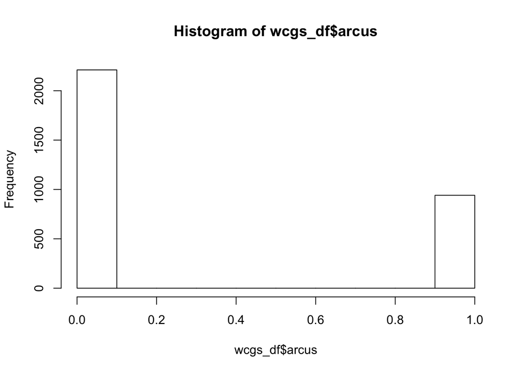

```r
hist(wcgs_df$arcus)
```

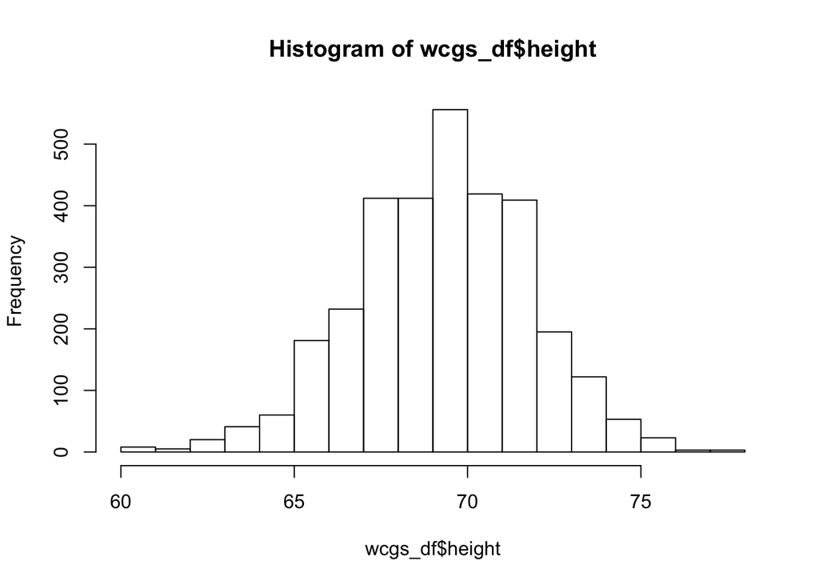

```r
hist(wcgs_df$height)
```

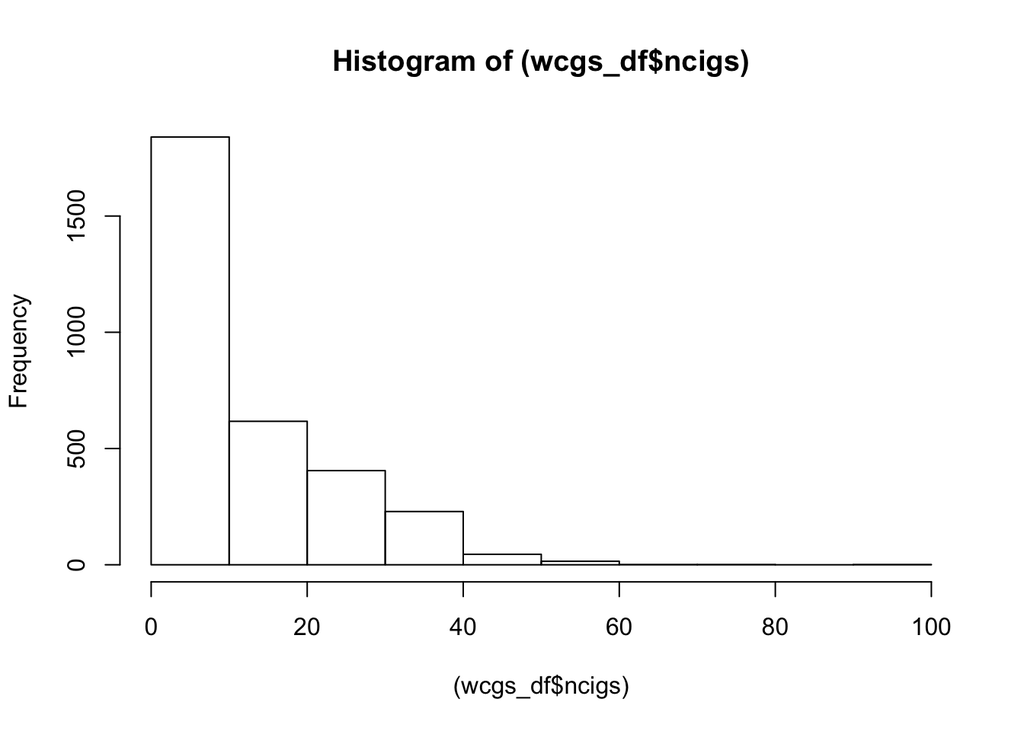

```r
hist((wcgs_df$ncigs))
```

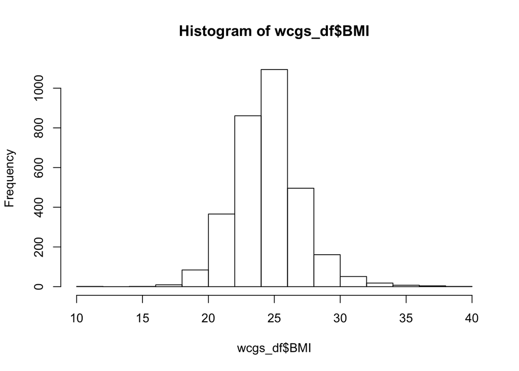

```r
hist(wcgs_df$BMI)
```

```r
# For histogram of arcus and ncigs, they are not normal distributed. The ncigs is skewed to the right side and arcus just have 2 kind of values, which is 0 and 1. The histogram of height and BMI are normal distributed. The coverage probability is the actual probability that the interval contains the true mean and it is ralated to alpha (1-alpha).
```